# Math 327, Chapter 2 HW Problem 2.4

David Oniani

September 11, 2019

Table B.3 contains data on the gasoline mileage performance of 32 automobiles.

```r
library(readxl)
mydata = read_excel ("./data-table-B3.XLS")
```

Fit a simple linear regression of gasoline mileage (y, miles per gallon or mpg) and engine displacement (x1, cubic inches).

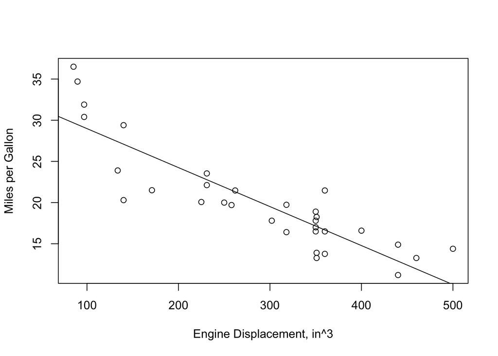

```r
fit1 = lm (y ~ x1, data=mydata)
plot (y ~ x1, data=mydata, ylab="Miles per Gallon", xlab="Engine Displacement, in^3")
abline (fit1)
```

```r
summary (fit1)
```

```
##
## Call:
## lm(formula = y ~ x1, data = mydata)
##
## Residuals:
##     Min      1Q  Median      3Q     Max
## -6.7923 -1.9752  0.0044  1.7677  6.8171
##
## Coefficients:
##              Estimate Std. Error t value Pr(>|t|)
## (Intercept) 33.722677   1.443903   23.36  < 2e-16 ***
## x1          -0.047360   0.004695  -10.09 3.74e-11 ***
## ---
## Signif. codes:  0 '***' 0.001 '**' 0.01 '*' 0.05 '.' 0.1 ' ' 1
##
## Residual standard error: 3.065 on 30 degrees of freedom
## Multiple R-squared:  0.7723, Adjusted R-squared:  0.7647
## F-statistic: 101.7 on 1 and 30 DF,  p-value: 3.743e-11
```

```r
confint (fit1)
```

```
##                   2.5 %      97.5 %
## (Intercept) 30.77383383 36.67151954
## x1          -0.05694883 -0.03777032
```

Q1: Interpret the Y-intercept and its confidence interval.

Q2: Interpret the slope and its confidence interval.

The mean Miles per Gallon value (response) decreases 0.047 Miles per Gallon per in^3 (Engine Displacement).

The mean slope changes between -0.057 and -0.038 Miles per Gallon per in^3 (Engine Displacement) with 95% confidence.

Q3: Interpret $R^2$ and the scatter plot.

$R^2 = 0.7723$ which means that approximately 77.23% of the variation in Miles per Gallon is explained by Engine Displacement/the linear model.

Scatter plot has a shape of a flat football demonstrating a fairly strong negative correlation between the dependent and independent variables. There are a few notable outliers.

```r
anova (fit1)
```

```
## Analysis of Variance Table
##
## Response: y
##           Df Sum Sq Mean Sq F value    Pr(>F)
## x1         1 955.72  955.72  101.74 3.743e-11 ***
## Residuals 30 281.82    9.39
## ---
## Signif. codes:  0 '***' 0.001 '**' 0.01 '*' 0.05 '.' 0.1 ' ' 1
```

Q4: Explain how $\hat\sigma=\sqrt{MS_{res}}$ can be obtained from the ANOVA above and state its value along with its units.

```r
predict (fit1, list (x1=275), interval = 'confidence')
```

```
##        fit      lwr      upr
## 1 20.69879 19.58807 21.80952
```

Q5: Interpret the confidence interval above:

The estimated mean response when Engine Displacement is 275 in^3 is between 19.588 and 21.810 Miles per Gallon with 95% confidence.

```r
predict (fit1, list (x1=275), interval = 'prediction')
```

```
##        fit      lwr      upr
## 1 20.69879 14.34147 27.05611
```

Q6: Interpret the prediction interval above:

The predicted response for an individual when Engine Displacement is 275 in^3 is between 14.341 and 27.056 Miles per Gallon with 95% confidence.

The next model fits mileage vs. vehicle weight (x10) in pounds (lbs).

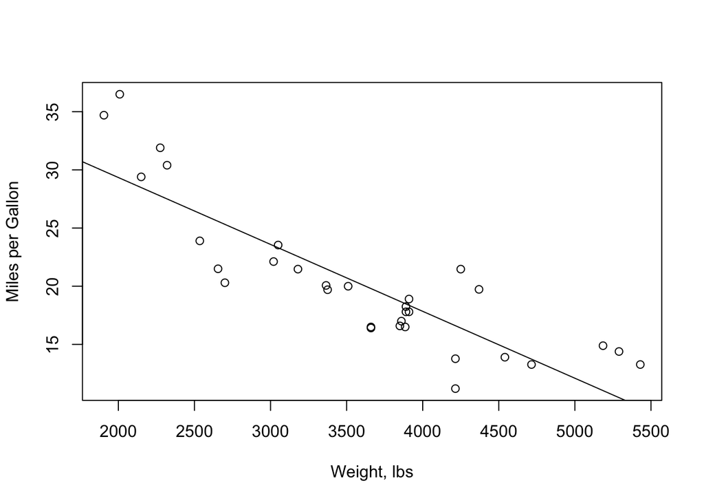

```r
fit2 = lm (y ~ x10, data=mydata)
plot (y ~ x10, data=mydata, ylab="Miles per Gallon", xlab="Weight, lbs")
abline (fit2)
```

```r
summary (fit2)
```

```
##
## Call:
## lm(formula = y ~ x10, data = mydata)
##
## Residuals:
##     Min      1Q  Median      3Q     Max
## -5.4093 -2.0352 -0.6714  3.0807  7.2026
##
## Coefficients:
##               Estimate Std. Error t value Pr(>|t|)
## (Intercept) 40.8524315  2.2789916  17.926  < 2e-16 ***
## x10         -0.0057516  0.0006149  -9.353 2.12e-10 ***
## ---
## Signif. codes:  0 '***' 0.001 '**' 0.01 '*' 0.05 '.' 0.1 ' ' 1
##
## Residual standard error: 3.246 on 30 degrees of freedom
## Multiple R-squared:  0.7446, Adjusted R-squared:  0.7361
## F-statistic: 87.48 on 1 and 30 DF,  p-value: 2.121e-10
```

```r
confint (fit2)
```

```
##                    2.5 %       97.5 %
## (Intercept) 36.198109758 45.506753166
## x10         -0.007007502 -0.004495762
```

Q7: Interpret the Y-intercept and its confidence interval.

The mean Miles per Gallon value (response) when Weight is zero is between 36.198 and 45.507 Miles per Gallon with 95% confidence. Y-intercept is not meaningful in this case as when the Weight is zero, there is no relationship between Weight and Miles per Gallon. This is the case as Weight being zero means having no vehicle at all.

Q8: Interpret the slope and its confidence interval.

The mean Miles per Gallon value (response) decreases 0.006 Miles per Gallon per lb (Weight).

The mean slope changes between -0.007 and -0.004 Miles per Gallon per lb (Weight) with 95% confidence.

Q9: Interpret $R^2$ and the scatter plot.

$R^2 = 0.7446$ which means that approximately 74.46% of the variation in Miles per Gallon is explained by Weight/the linear model.

Scatter plot has a shape of a flat football demonstrating a fairly strong negative correlation between the dependent and independent variables. There are a few notable outliers.

```r
anova (fit2)
```

```
## Analysis of Variance Table
##
## Response: y
##           Df Sum Sq Mean Sq F value    Pr(>F)
## x10        1 921.53  921.53  87.482 2.121e-10 ***
## Residuals 30 316.02   10.53
## ---
## Signif. codes:  0 '***' 0.001 '**' 0.01 '*' 0.05 '.' 0.1 ' ' 1
```

Q10: Explain how $\hat\sigma=\sqrt{MS_{res}}$ can be obtained from the ANOVA above and state its value along with its units.

```r
predict (fit2, list (x10=2750), interval = 'confidence')
```

```
##        fit      lwr      upr
## 1 25.03544 23.46156 26.60932
```

Q11: Interpret the confidence interval above:

```r
predict (fit2, list (x10=2750), interval = 'prediction')
```

```
##        fit      lwr      upr
## 1 25.03544 18.22277 31.84812
```

Q12: Interpret the prediction interval above:

The predicted response for an individual when Weight is 2750 lbs is between 18.223 and 31.848 Miles per Gallon with 95% confidence.

Q13: Overall, which model would you prefer and why?

Miles per Gallon VS Engine Displacement is a better model than Miles per Gallon VS Weight. This is simply because Engine Displacement is a better measure and indicator for a change in Miles per Gallon. Simply put, Engine Displacement is a better Explanatory Variable than the Weight of a vehicle.